# Risk Factor Analysis

## Outcome Variable

**Outcome Variable:** ever_co

## Predictor Variables

**Intervention Variable:** parity

**Adjustment Set:**

- arm
- W_mage
- meducyrs
- feducyrs
- hhwealth_quart
- W_mhtcm
- W_mwtkg
- W_mbmi
- vagbrth
- W_nrooms
- impsan
- delta_W_mage
- delta_meducyrs
- delta_feducyrs
- delta_hhwealth_quart
- delta_W_mhtcm
- delta_W_mwtkg
- delta_W_mbmi
- delta_vagbrth
- delta_W_nrooms
- delta_impsan

## Stratifying Variables

The analysis was stratified on these variable(s):

- agecat
- studyid
- country

## Data Summary

| agecat | studyid | country | parity | ever_co | n_cell | n |
| --- | --- | --- | --- | --- | --- | --- |
| 0-24 months | COHORTS | GUATEMALA | 1 | 0 | 191 | 1341 |
| 0-24 months | COHORTS | GUATEMALA | 1 | 1 | 17 | 1341 |
| 0-24 months | COHORTS | GUATEMALA | 2 | 0 | 164 | 1341 |
| 0-24 months | COHORTS | GUATEMALA | 2 | 1 | 23 | 1341 |
| 0-24 months | COHORTS | GUATEMALA | 3+ | 0 | 838 | 1341 |
| 0-24 months | COHORTS | GUATEMALA | 3+ | 1 | 108 | 1341 |
| 0-24 months | COHORTS | INDIA | 1 | 0 | 757 | 4623 |
| 0-24 months | COHORTS | INDIA | 1 | 1 | 53 | 4623 |
| 0-24 months | COHORTS | INDIA | 2 | 0 | 1093 | 4623 |
| 0-24 months | COHORTS | INDIA | 2 | 1 | 91 | 4623 |
| 0-24 months | COHORTS | INDIA | 3+ | 0 | 2307 | 4623 |
| 0-24 months | COHORTS | INDIA | 3+ | 1 | 322 | 4623 |
| 0-24 months | COHORTS | PHILIPPINES | 1 | 0 | 586 | 3045 |
| 0-24 months | COHORTS | PHILIPPINES | 1 | 1 | 91 | 3045 |
| 0-24 months | COHORTS | PHILIPPINES | 2 | 0 | 572 | 3045 |
| 0-24 months | COHORTS | PHILIPPINES | 2 | 1 | 110 | 3045 |
| 0-24 months | COHORTS | PHILIPPINES | 3+ | 0 | 1327 | 3045 |
| 0-24 months | COHORTS | PHILIPPINES | 3+ | 1 | 359 | 3045 |
| 0-24 months | GMS-Nepal | NEPAL | 1 | 0 | 151 | 686 |
| 0-24 months | GMS-Nepal | NEPAL | 1 | 1 | 52 | 686 |
| 0-24 months | GMS-Nepal | NEPAL | 2 | 0 | 134 | 686 |
| 0-24 months | GMS-Nepal | NEPAL | 2 | 1 | 46 | 686 |
| 0-24 months | GMS-Nepal | NEPAL | 3+ | 0 | 199 | 686 |
| 0-24 months | GMS-Nepal | NEPAL | 3+ | 1 | 104 | 686 |
| 0-24 months | JiVitA-3 | BANGLADESH | 1 | 0 | 9121 | 26923 |
| 0-24 months | JiVitA-3 | BANGLADESH | 1 | 1 | 985 | 26923 |
| 0-24 months | JiVitA-3 | BANGLADESH | 2 | 0 | 8216 | 26923 |
| 0-24 months | JiVitA-3 | BANGLADESH | 2 | 1 | 711 | 26923 |
| 0-24 months | JiVitA-3 | BANGLADESH | 3+ | 0 | 7194 | 26923 |
| 0-24 months | JiVitA-3 | BANGLADESH | 3+ | 1 | 696 | 26923 |

[output cut: 168 more lines]

The following strata were considered:

- agecat: 0-24 months, studyid: COHORTS, country: GUATEMALA
- agecat: 0-24 months, studyid: COHORTS, country: INDIA
- agecat: 0-24 months, studyid: COHORTS, country: PHILIPPINES
- agecat: 0-24 months, studyid: GMS-Nepal, country: NEPAL
- agecat: 0-24 months, studyid: JiVitA-3, country: BANGLADESH
- agecat: 0-24 months, studyid: Keneba, country: GAMBIA
- agecat: 0-24 months, studyid: PROVIDE, country: BANGLADESH
- agecat: 0-24 months, studyid: SAS-CompFeed, country: INDIA
- agecat: 0-24 months, studyid: SAS-FoodSuppl, country: INDIA
- agecat: 0-24 months, studyid: TanzaniaChild2, country: TANZANIA, UNITED REPUBLIC OF
- agecat: 0-24 months, studyid: ZVITAMBO, country: ZIMBABWE
- agecat: 0-6 months, studyid: COHORTS, country: GUATEMALA
- agecat: 0-6 months, studyid: COHORTS, country: INDIA
- agecat: 0-6 months, studyid: COHORTS, country: PHILIPPINES
- agecat: 0-6 months, studyid: GMS-Nepal, country: NEPAL
- agecat: 0-6 months, studyid: JiVitA-3, country: BANGLADESH
- agecat: 0-6 months, studyid: Keneba, country: GAMBIA
- agecat: 0-6 months, studyid: PROVIDE, country: BANGLADESH
- agecat: 0-6 months, studyid: SAS-CompFeed, country: INDIA
- agecat: 0-6 months, studyid: SAS-FoodSuppl, country: INDIA
- agecat: 0-6 months, studyid: TanzaniaChild2, country: TANZANIA, UNITED REPUBLIC OF
- agecat: 0-6 months, studyid: ZVITAMBO, country: ZIMBABWE
- agecat: 6-24 months, studyid: COHORTS, country: GUATEMALA
- agecat: 6-24 months, studyid: COHORTS, country: INDIA
- agecat: 6-24 months, studyid: COHORTS, country: PHILIPPINES
- agecat: 6-24 months, studyid: GMS-Nepal, country: NEPAL
- agecat: 6-24 months, studyid: JiVitA-3, country: BANGLADESH
- agecat: 6-24 months, studyid: Keneba, country: GAMBIA
- agecat: 6-24 months, studyid: PROVIDE, country: BANGLADESH
- agecat: 6-24 months, studyid: SAS-CompFeed, country: INDIA
- agecat: 6-24 months, studyid: SAS-FoodSuppl, country: INDIA
- agecat: 6-24 months, studyid: TanzaniaChild2, country: TANZANIA, UNITED REPUBLIC OF
- agecat: 6-24 months, studyid: ZVITAMBO, country: ZIMBABWE

### Dropped Strata

Some strata were dropped due to rare outcomes:

- agecat: 0-24 months, studyid: SAS-FoodSuppl, country: INDIA
- agecat: 0-6 months, studyid: COHORTS, country: GUATEMALA
- agecat: 0-6 months, studyid: Keneba, country: GAMBIA
- agecat: 0-6 months, studyid: SAS-FoodSuppl, country: INDIA
- agecat: 6-24 months, studyid: SAS-FoodSuppl, country: INDIA

## Methods Detail

We’re interested in the causal parameters $E[Y_a]$ for all values of $a \in \mathcal{A}$. These parameters represent the mean outcome if, possibly contrary to fact, we intervened to set all units to have $A=a$. Under the randomization and positivity assumptions, these are identified by the statistical parameters $\psi_a=E_W[E_{Y|A,W}(Y|A=a,W)]$. In addition, we’re interested in the mean of $Y$, $E[Y]$ under no intervention (the observed mean). We will estimate these parameters by using SuperLearner to fit the relevant likelihood factors – $E_{Y|A,W}(Y|A=a,W)$ and $p(A=a|W)$, and then updating our likelihood fit using a joint TMLE.

For unadjusted analyses ($W=\{\}$), initial likelihoods were estimated using Lrnr_glm to estimate the simple $E(Y|A)$ and Lrnr_mean to estimate $p(A)$. For adjusted analyses, a small library containing Lrnr_glmnet, Lrnr_xgboost, and Lrnr_mean was used.

Having estimated these parameters, we will then use the delta method to estimate relative risks and attributable risks relative to a prespecified baseline level of $A$.

# Results Detail

## Results Plots

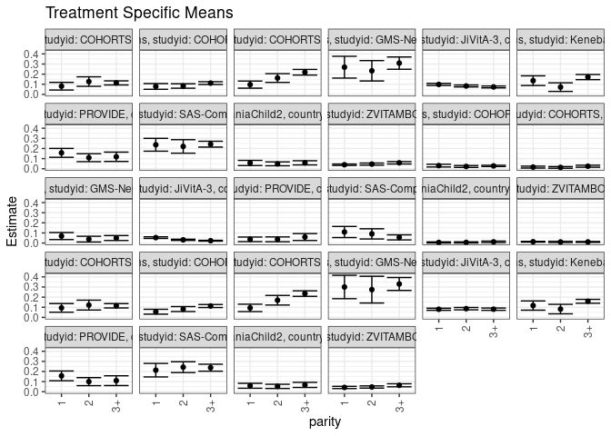

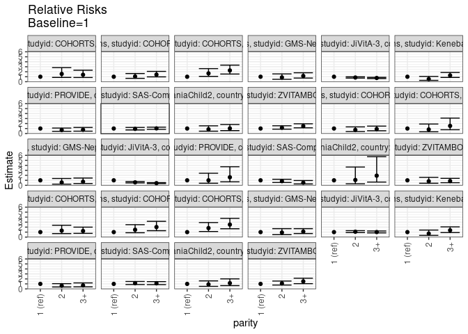

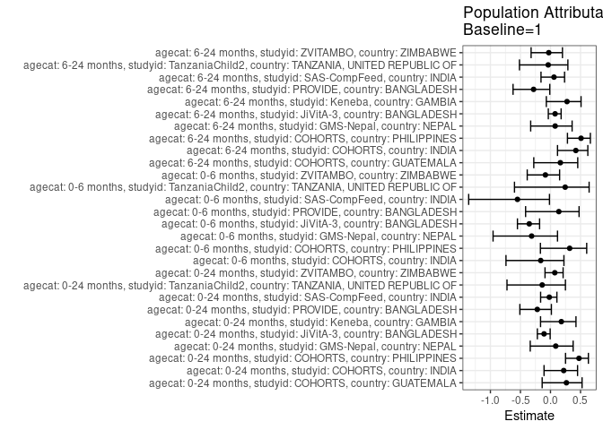

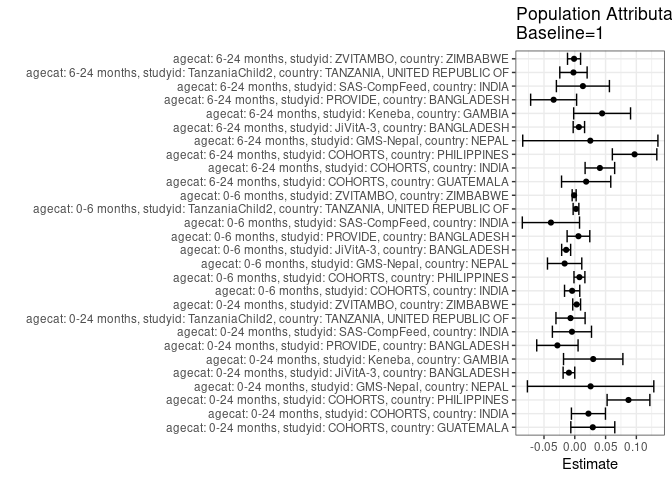

## Results Table

### Parameter: TSM

| agecat | studyid | country | intervention_level | baseline_level | estimate | ci_lower | ci_upper |
| --- | --- | --- | --- | --- | --- | --- | --- |
| 0-24 months | COHORTS | GUATEMALA | 1 | NA | 0.0811011 | 0.0432275 | 0.1189746 |
| 0-24 months | COHORTS | GUATEMALA | 2 | NA | 0.1265369 | 0.0795162 | 0.1735576 |
| 0-24 months | COHORTS | GUATEMALA | 3+ | NA | 0.1132857 | 0.0930985 | 0.1334730 |
| 0-24 months | COHORTS | INDIA | 1 | NA | 0.0786115 | 0.0503334 | 0.1068896 |
| 0-24 months | COHORTS | INDIA | 2 | NA | 0.0827604 | 0.0610421 | 0.1044788 |
| 0-24 months | COHORTS | INDIA | 3+ | NA | 0.1115757 | 0.0979558 | 0.1251956 |
| 0-24 months | COHORTS | PHILIPPINES | 1 | NA | 0.0966966 | 0.0615211 | 0.1318721 |
| 0-24 months | COHORTS | PHILIPPINES | 2 | NA | 0.1617938 | 0.1186347 | 0.2049529 |
| 0-24 months | COHORTS | PHILIPPINES | 3+ | NA | 0.2187905 | 0.1908525 | 0.2467285 |
| 0-24 months | GMS-Nepal | NEPAL | 1 | NA | 0.2687603 | 0.1611999 | 0.3763207 |
| 0-24 months | GMS-Nepal | NEPAL | 2 | NA | 0.2332885 | 0.1326755 | 0.3339014 |
| 0-24 months | GMS-Nepal | NEPAL | 3+ | NA | 0.3089735 | 0.2482925 | 0.3696544 |
| 0-24 months | JiVitA-3 | BANGLADESH | 1 | NA | 0.0983430 | 0.0879570 | 0.1087290 |
| 0-24 months | JiVitA-3 | BANGLADESH | 2 | NA | 0.0830925 | 0.0735960 | 0.0925890 |
| 0-24 months | JiVitA-3 | BANGLADESH | 3+ | NA | 0.0736705 | 0.0644883 | 0.0828528 |
| 0-24 months | Keneba | GAMBIA | 1 | NA | 0.1354941 | 0.0874585 | 0.1835297 |
| 0-24 months | Keneba | GAMBIA | 2 | NA | 0.0719677 | 0.0293740 | 0.1145615 |
| 0-24 months | Keneba | GAMBIA | 3+ | NA | 0.1711611 | 0.1457427 | 0.1965795 |
| 0-24 months | PROVIDE | BANGLADESH | 1 | NA | 0.1567968 | 0.1130777 | 0.2005159 |
| 0-24 months | PROVIDE | BANGLADESH | 2 | NA | 0.1090681 | 0.0698125 | 0.1483237 |
| 0-24 months | PROVIDE | BANGLADESH | 3+ | NA | 0.1180410 | 0.0719718 | 0.1641102 |
| 0-24 months | SAS-CompFeed | INDIA | 1 | NA | 0.2365909 | 0.1733777 | 0.2998042 |
| 0-24 months | SAS-CompFeed | INDIA | 2 | NA | 0.2202750 | 0.1535240 | 0.2870259 |
| 0-24 months | SAS-CompFeed | INDIA | 3+ | NA | 0.2425453 | 0.2137468 | 0.2713437 |
| 0-24 months | TanzaniaChild2 | TANZANIA, UNITED REPUBLIC OF | 1 | NA | 0.0569726 | 0.0314413 | 0.0825039 |
| 0-24 months | TanzaniaChild2 | TANZANIA, UNITED REPUBLIC OF | 2 | NA | 0.0481248 | 0.0290086 | 0.0672409 |
| 0-24 months | TanzaniaChild2 | TANZANIA, UNITED REPUBLIC OF | 3+ | NA | 0.0581484 | 0.0373512 | 0.0789457 |
| 0-24 months | ZVITAMBO | ZIMBABWE | 1 | NA | 0.0393562 | 0.0323636 | 0.0463487 |
| 0-24 months | ZVITAMBO | ZIMBABWE | 2 | NA | 0.0455989 | 0.0351384 | 0.0560594 |
| 0-24 months | ZVITAMBO | ZIMBABWE | 3+ | NA | 0.0586065 | 0.0467760 | 0.0704369 |

[output cut: 54 more lines]

### Parameter: E(Y)

| agecat | studyid | country | intervention_level | baseline_level | estimate | ci_lower | ci_upper |
| --- | --- | --- | --- | --- | --- | --- | --- |
| 0-24 months | COHORTS | GUATEMALA | NA | NA | 0.1103654 | 0.0935883 | 0.1271425 |
| 0-24 months | COHORTS | INDIA | NA | NA | 0.1008003 | 0.0921209 | 0.1094798 |
| 0-24 months | COHORTS | PHILIPPINES | NA | NA | 0.1839080 | 0.1701456 | 0.1976705 |
| 0-24 months | GMS-Nepal | NEPAL | NA | NA | 0.2944606 | 0.2603274 | 0.3285938 |
| 0-24 months | JiVitA-3 | BANGLADESH | NA | NA | 0.0888460 | 0.0849398 | 0.0927521 |
| 0-24 months | Keneba | GAMBIA | NA | NA | 0.1654098 | 0.1490771 | 0.1817424 |
| 0-24 months | PROVIDE | BANGLADESH | NA | NA | 0.1285714 | 0.1037574 | 0.1533855 |
| 0-24 months | SAS-CompFeed | INDIA | NA | NA | 0.2319894 | 0.1917264 | 0.2722524 |
| 0-24 months | TanzaniaChild2 | TANZANIA, UNITED REPUBLIC OF | NA | NA | 0.0500636 | 0.0412578 | 0.0588694 |
| 0-24 months | ZVITAMBO | ZIMBABWE | NA | NA | 0.0423929 | 0.0390482 | 0.0457376 |
| 0-6 months | COHORTS | INDIA | NA | NA | 0.0263336 | 0.0216247 | 0.0310424 |
| 0-6 months | COHORTS | PHILIPPINES | NA | NA | 0.0236531 | 0.0182537 | 0.0290525 |
| 0-6 months | GMS-Nepal | NEPAL | NA | NA | 0.0524781 | 0.0357793 | 0.0691770 |
| 0-6 months | JiVitA-3 | BANGLADESH | NA | NA | 0.0396778 | 0.0371765 | 0.0421791 |
| 0-6 months | PROVIDE | BANGLADESH | NA | NA | 0.0428571 | 0.0278427 | 0.0578716 |
| 0-6 months | SAS-CompFeed | INDIA | NA | NA | 0.0704787 | 0.0478990 | 0.0930584 |
| 0-6 months | TanzaniaChild2 | TANZANIA, UNITED REPUBLIC OF | NA | NA | 0.0080611 | 0.0044503 | 0.0116719 |
| 0-6 months | ZVITAMBO | ZIMBABWE | NA | NA | 0.0120621 | 0.0102437 | 0.0138805 |
| 6-24 months | COHORTS | GUATEMALA | NA | NA | 0.1123039 | 0.0945135 | 0.1300942 |
| 6-24 months | COHORTS | INDIA | NA | NA | 0.0965883 | 0.0877969 | 0.1053797 |
| 6-24 months | COHORTS | PHILIPPINES | NA | NA | 0.1908832 | 0.1763448 | 0.2054216 |
| 6-24 months | GMS-Nepal | NEPAL | NA | NA | 0.3254237 | 0.2875855 | 0.3632619 |
| 6-24 months | JiVitA-3 | BANGLADESH | NA | NA | 0.0869213 | 0.0822621 | 0.0915805 |
| 6-24 months | Keneba | GAMBIA | NA | NA | 0.1612064 | 0.1447669 | 0.1776460 |
| 6-24 months | PROVIDE | BANGLADESH | NA | NA | 0.1221498 | 0.0962275 | 0.1480722 |
| 6-24 months | SAS-CompFeed | INDIA | NA | NA | 0.2260619 | 0.1909133 | 0.2612105 |
| 6-24 months | TanzaniaChild2 | TANZANIA, UNITED REPUBLIC OF | NA | NA | 0.0563948 | 0.0462467 | 0.0665428 |
| 6-24 months | ZVITAMBO | ZIMBABWE | NA | NA | 0.0410655 | 0.0373248 | 0.0448061 |

### Parameter: RR

| agecat | studyid | country | intervention_level | baseline_level | estimate | ci_lower | ci_upper |
| --- | --- | --- | --- | --- | --- | --- | --- |
| 0-24 months | COHORTS | GUATEMALA | 1 | 1 | 1.0000000 | 1.0000000 | 1.0000000 |
| 0-24 months | COHORTS | GUATEMALA | 2 | 1 | 1.5602374 | 0.8600530 | 2.8304546 |
| 0-24 months | COHORTS | GUATEMALA | 3+ | 1 | 1.3968464 | 0.8478623 | 2.3012933 |
| 0-24 months | COHORTS | INDIA | 1 | 1 | 1.0000000 | 1.0000000 | 1.0000000 |
| 0-24 months | COHORTS | INDIA | 2 | 1 | 1.0527772 | 0.6750592 | 1.6418410 |
| 0-24 months | COHORTS | INDIA | 3+ | 1 | 1.4193300 | 0.9716127 | 2.0733547 |
| 0-24 months | COHORTS | PHILIPPINES | 1 | 1 | 1.0000000 | 1.0000000 | 1.0000000 |
| 0-24 months | COHORTS | PHILIPPINES | 2 | 1 | 1.6732101 | 1.0666608 | 2.6246696 |
| 0-24 months | COHORTS | PHILIPPINES | 3+ | 1 | 2.2626487 | 1.5393067 | 3.3258994 |
| 0-24 months | GMS-Nepal | NEPAL | 1 | 1 | 1.0000000 | 1.0000000 | 1.0000000 |
| 0-24 months | GMS-Nepal | NEPAL | 2 | 1 | 0.8680170 | 0.4819294 | 1.5634104 |
| 0-24 months | GMS-Nepal | NEPAL | 3+ | 1 | 1.1496248 | 0.7358973 | 1.7959532 |
| 0-24 months | JiVitA-3 | BANGLADESH | 1 | 1 | 1.0000000 | 1.0000000 | 1.0000000 |
| 0-24 months | JiVitA-3 | BANGLADESH | 2 | 1 | 0.8449250 | 0.7267021 | 0.9823809 |
| 0-24 months | JiVitA-3 | BANGLADESH | 3+ | 1 | 0.7491182 | 0.6376605 | 0.8800578 |
| 0-24 months | Keneba | GAMBIA | 1 | 1 | 1.0000000 | 1.0000000 | 1.0000000 |
| 0-24 months | Keneba | GAMBIA | 2 | 1 | 0.5311501 | 0.2663803 | 1.0590890 |
| 0-24 months | Keneba | GAMBIA | 3+ | 1 | 1.2632364 | 0.8610854 | 1.8532031 |
| 0-24 months | PROVIDE | BANGLADESH | 1 | 1 | 1.0000000 | 1.0000000 | 1.0000000 |
| 0-24 months | PROVIDE | BANGLADESH | 2 | 1 | 0.6956015 | 0.4420006 | 1.0947077 |
| 0-24 months | PROVIDE | BANGLADESH | 3+ | 1 | 0.7528278 | 0.4669080 | 1.2138358 |
| 0-24 months | SAS-CompFeed | INDIA | 1 | 1 | 1.0000000 | 1.0000000 | 1.0000000 |
| 0-24 months | SAS-CompFeed | INDIA | 2 | 1 | 0.9310372 | 0.7152936 | 1.2118523 |
| 0-24 months | SAS-CompFeed | INDIA | 3+ | 1 | 1.0251672 | 0.8295032 | 1.2669847 |
| 0-24 months | TanzaniaChild2 | TANZANIA, UNITED REPUBLIC OF | 1 | 1 | 1.0000000 | 1.0000000 | 1.0000000 |
| 0-24 months | TanzaniaChild2 | TANZANIA, UNITED REPUBLIC OF | 2 | 1 | 0.8447004 | 0.4642019 | 1.5370872 |
| 0-24 months | TanzaniaChild2 | TANZANIA, UNITED REPUBLIC OF | 3+ | 1 | 1.0206385 | 0.5752447 | 1.8108866 |
| 0-24 months | ZVITAMBO | ZIMBABWE | 1 | 1 | 1.0000000 | 1.0000000 | 1.0000000 |
| 0-24 months | ZVITAMBO | ZIMBABWE | 2 | 1 | 1.1586221 | 0.8671191 | 1.5481208 |
| 0-24 months | ZVITAMBO | ZIMBABWE | 3+ | 1 | 1.4891306 | 1.1383376 | 1.9480250 |

[output cut: 54 more lines]

### Parameter: PAR

| agecat | studyid | country | intervention_level | baseline_level | estimate | ci_lower | ci_upper |
| --- | --- | --- | --- | --- | --- | --- | --- |
| 0-24 months | COHORTS | GUATEMALA | 1 | NA | 0.0292643 | -0.0064312 | 0.0649599 |
| 0-24 months | COHORTS | INDIA | 1 | NA | 0.0221888 | -0.0054547 | 0.0498324 |
| 0-24 months | COHORTS | PHILIPPINES | 1 | NA | 0.0872114 | 0.0524970 | 0.1219259 |
| 0-24 months | GMS-Nepal | NEPAL | 1 | NA | 0.0257004 | -0.0769445 | 0.1283452 |
| 0-24 months | JiVitA-3 | BANGLADESH | 1 | NA | -0.0094970 | -0.0189493 | -0.0000447 |
| 0-24 months | Keneba | GAMBIA | 1 | NA | 0.0299156 | -0.0182900 | 0.0781213 |
| 0-24 months | PROVIDE | BANGLADESH | 1 | NA | -0.0282254 | -0.0617988 | 0.0053480 |
| 0-24 months | SAS-CompFeed | INDIA | 1 | NA | -0.0046015 | -0.0363694 | 0.0271664 |
| 0-24 months | TanzaniaChild2 | TANZANIA, UNITED REPUBLIC OF | 1 | NA | -0.0069090 | -0.0305876 | 0.0167697 |
| 0-24 months | ZVITAMBO | ZIMBABWE | 1 | NA | 0.0030368 | -0.0033317 | 0.0094052 |
| 0-6 months | COHORTS | INDIA | 1 | NA | -0.0042803 | -0.0166616 | 0.0081009 |
| 0-6 months | COHORTS | PHILIPPINES | 1 | NA | 0.0075459 | -0.0013239 | 0.0164157 |
| 0-6 months | GMS-Nepal | NEPAL | 1 | NA | -0.0164874 | -0.0443355 | 0.0113608 |
| 0-6 months | JiVitA-3 | BANGLADESH | 1 | NA | -0.0140178 | -0.0213121 | -0.0067234 |
| 0-6 months | PROVIDE | BANGLADESH | 1 | NA | 0.0059568 | -0.0124634 | 0.0243770 |
| 0-6 months | SAS-CompFeed | INDIA | 1 | NA | -0.0387419 | -0.0852113 | 0.0077275 |
| 0-6 months | TanzaniaChild2 | TANZANIA, UNITED REPUBLIC OF | 1 | NA | 0.0019710 | -0.0026802 | 0.0066221 |
| 0-6 months | ZVITAMBO | ZIMBABWE | 1 | NA | -0.0010220 | -0.0042405 | 0.0021965 |
| 6-24 months | COHORTS | GUATEMALA | 1 | NA | 0.0184663 | -0.0214946 | 0.0584272 |
| 6-24 months | COHORTS | INDIA | 1 | NA | 0.0407586 | 0.0167677 | 0.0647494 |
| 6-24 months | COHORTS | PHILIPPINES | 1 | NA | 0.0971184 | 0.0610130 | 0.1332238 |
| 6-24 months | GMS-Nepal | NEPAL | 1 | NA | 0.0252307 | -0.0845510 | 0.1350123 |
| 6-24 months | JiVitA-3 | BANGLADESH | 1 | NA | 0.0066525 | -0.0026045 | 0.0159096 |
| 6-24 months | Keneba | GAMBIA | 1 | NA | 0.0443860 | -0.0017993 | 0.0905713 |
| 6-24 months | PROVIDE | BANGLADESH | 1 | NA | -0.0343598 | -0.0716800 | 0.0029604 |
| 6-24 months | SAS-CompFeed | INDIA | 1 | NA | 0.0131904 | -0.0298698 | 0.0562506 |
| 6-24 months | TanzaniaChild2 | TANZANIA, UNITED REPUBLIC OF | 1 | NA | -0.0021488 | -0.0243421 | 0.0200445 |
| 6-24 months | ZVITAMBO | ZIMBABWE | 1 | NA | -0.0011944 | -0.0118002 | 0.0094114 |

### Parameter: PAF

| agecat | studyid | country | intervention_level | baseline_level | estimate | ci_lower | ci_upper |
| --- | --- | --- | --- | --- | --- | --- | --- |
| 0-24 months | COHORTS | GUATEMALA | 1 | NA | 0.2651587 | -0.1387100 | 0.5257864 |
| 0-24 months | COHORTS | INDIA | 1 | NA | 0.2201266 | -0.1072105 | 0.4506893 |
| 0-24 months | COHORTS | PHILIPPINES | 1 | NA | 0.4742121 | 0.2507210 | 0.6310414 |
| 0-24 months | GMS-Nepal | NEPAL | 1 | NA | 0.0872795 | -0.3371580 | 0.3769930 |
| 0-24 months | JiVitA-3 | BANGLADESH | 1 | NA | -0.1068932 | -0.2184494 | -0.0055507 |
| 0-24 months | Keneba | GAMBIA | 1 | NA | 0.1808578 | -0.1653392 | 0.4242072 |
| 0-24 months | PROVIDE | BANGLADESH | 1 | NA | -0.2195308 | -0.5096707 | 0.0148478 |
| 0-24 months | SAS-CompFeed | INDIA | 1 | NA | -0.0198350 | -0.1643269 | 0.1067256 |
| 0-24 months | TanzaniaChild2 | TANZANIA, UNITED REPUBLIC OF | 1 | NA | -0.1380038 | -0.7241614 | 0.2488797 |
| 0-24 months | ZVITAMBO | ZIMBABWE | 1 | NA | 0.0716340 | -0.0911081 | 0.2101027 |
| 0-6 months | COHORTS | INDIA | 1 | NA | -0.1625432 | -0.7409483 | 0.2236951 |
| 0-6 months | COHORTS | PHILIPPINES | 1 | NA | 0.3190239 | -0.1676142 | 0.6028410 |
| 0-6 months | GMS-Nepal | NEPAL | 1 | NA | -0.3141762 | -0.9558762 | 0.1169895 |
| 0-6 months | JiVitA-3 | BANGLADESH | 1 | NA | -0.3532900 | -0.5501743 | -0.1814115 |
| 0-6 months | PROVIDE | BANGLADESH | 1 | NA | 0.1389914 | -0.4142101 | 0.4757951 |
| 0-6 months | SAS-CompFeed | INDIA | 1 | NA | -0.5496970 | -1.3618079 | -0.0168315 |
| 0-6 months | TanzaniaChild2 | TANZANIA, UNITED REPUBLIC OF | 1 | NA | 0.2445029 | -0.5993898 | 0.6431289 |
| 0-6 months | ZVITAMBO | ZIMBABWE | 1 | NA | -0.0847265 | -0.3872783 | 0.1518417 |
| 6-24 months | COHORTS | GUATEMALA | 1 | NA | 0.1644314 | -0.2781668 | 0.4537686 |
| 6-24 months | COHORTS | INDIA | 1 | NA | 0.4219823 | 0.1170697 | 0.6215959 |
| 6-24 months | COHORTS | PHILIPPINES | 1 | NA | 0.5087844 | 0.2823869 | 0.6637565 |
| 6-24 months | GMS-Nepal | NEPAL | 1 | NA | 0.0775318 | -0.3296810 | 0.3600362 |
| 6-24 months | JiVitA-3 | BANGLADESH | 1 | NA | 0.0765351 | -0.0361983 | 0.1770036 |
| 6-24 months | Keneba | GAMBIA | 1 | NA | 0.2753364 | -0.0692081 | 0.5088540 |
| 6-24 months | PROVIDE | BANGLADESH | 1 | NA | -0.2812922 | -0.6231657 | -0.0114246 |
| 6-24 months | SAS-CompFeed | INDIA | 1 | NA | 0.0583485 | -0.1579165 | 0.2342215 |
| 6-24 months | TanzaniaChild2 | TANZANIA, UNITED REPUBLIC OF | 1 | NA | -0.0381025 | -0.5167272 | 0.2894854 |
| 6-24 months | ZVITAMBO | ZIMBABWE | 1 | NA | -0.0290856 | -0.3227116 | 0.1993589 |